Here we are going to examine the dataset scraped from the http://angband.oook.cz/ladder-browse.php?v=Angband

We scraped the data with angScrape.r

We cleaned the data with angClean.r

Here the aim is to examine the data, pull out nuggets of information, and see what if anything, we can determine about winning this game.

```r
#load the cleaned data set

library(tidyverse)
load(file = "clean_df.RData")

#examine the first 6 rows
head(clean_df)
```

```
##   rank angband rank         name     race   class level experience
## 1  127           18 Elrathi Seth High-Elf Warrior    50      1e+08
## 2  128           19        Ziggy High-Elf  Ranger    50      1e+08
## 3  129           20        Oyvin  Dunadan Warrior    50      1e+08
## 4  130           21         Sara High-Elf    Mage    50      1e+08
## 5  131           22         Rezi    Gnome    Mage    50      1e+08
## 6   62            1      Aragorn  Dunadan  Ranger    50      1e+08
##   turncount max depth       variant comments             updated
## 1        NA        NA Angband 2.8.3       43 2005-01-05 22:44:00
## 2        NA        NA Angband 3.0.1       10 2002-10-24 18:58:00
## 3        NA        NA Angband 3.0.1        4 2002-12-09 13:46:00
## 4        NA        NA Angband 3.0.1        4 2003-01-25 23:10:00
## 5        NA        NA Angband 3.0.1       34 2003-07-02 18:02:00
## 6        NA       127 Angband 3.0.5       16 2005-06-26 00:46:00
##                          by                                          links
## 1   Lord_Melkor@hotmail.com  http://angband.oook.cz/ladder-show.php?id=495
## 2         brabson@nc.rr.com  http://angband.oook.cz/ladder-show.php?id=622
## 3            c.smith@ucc.ie  http://angband.oook.cz/ladder-show.php?id=813
## 4 advanced_bridge@yahoo.com http://angband.oook.cz/ladder-show.php?id=1006
## 5          andysoft@usa.net http://angband.oook.cz/ladder-show.php?id=1249
## 6           andrew@msri.org http://angband.oook.cz/ladder-show.php?id=2727
##   status
## 1 winner
## 2 winner
## 3 winner
## 4 winner
## 5 winner
## 6 winner
```

```r
#examine the last 6 rows
tail(clean_df)
```

```
##       rank angband rank         name     race   class level experience
## 5164 16194         5144     Bregalar    Dwarf Paladin     1          0
## 5165 16197         5145         User    Gnome    Mage     1          0
## 5166 16236         5153          Ent      Ent  Priest     1          0
## 5167 16237         5154 Isadrielinde Half-Elf  Ranger     1          0
## 5168 16238         5155        Filaa Half-Elf  Ranger     1          0
## 5169 16239         5156 Aren Darkday Half-Elf   Rogue     1          0
##      turncount max depth       variant comments             updated
## 5164        11        NA Angband 3.a.0        1 2016-12-10 09:27:00
## 5165        NA        NA Angband 4.1.0        0 2017-07-19 21:10:00
## 5166         3        NA Angband 4.1.2        3 2018-07-03 01:43:00
## 5167        NA        NA Angband 2.8.3        0 2018-07-28 17:57:00
## 5168        NA        NA Angband 2.8.3        0 2018-07-29 13:11:00
## 5169       171         1 Angband 3.5.1        2 2019-01-18 16:09:00
##                             by
## 5164                      debo
## 5165                   AndreyB
## 5166                    wobbly
## 5167 uncategorised@outlook.com
## 5168 uncategorised@outlook.com
## 5169                     MITZE
##                                                links status
## 5164 http://angband.oook.cz/ladder-show.php?id=19965  alive
## 5165 http://angband.oook.cz/ladder-show.php?id=20936  alive
## 5166 http://angband.oook.cz/ladder-show.php?id=21796   dead
## 5167 http://angband.oook.cz/ladder-show.php?id=21856   dead
## 5168 http://angband.oook.cz/ladder-show.php?id=21858  alive
## 5169 http://angband.oook.cz/ladder-show.php?id=22235   dead
```

```r
#Take a glimpse at the table
glimpse(clean_df)
```

```
## Observations: 5,166
## Variables: 15
## $ rank           <int> 127, 128, 129, 130, 131, 62, 73, 74, 75, 76, 11...
## $ `angband rank` <int> 18, 19, 20, 21, 22, 1, 2, 3, 4, 5, 9, 10, 11, 1...
## $ name           <chr> "Elrathi Seth", "Ziggy", "Oyvin", "Sara", "Rezi...
## $ race           <chr> "High-Elf", "High-Elf", "Dunadan", "High-Elf", ...
## $ class          <chr> "Warrior", "Ranger", "Warrior", "Mage", "Mage",...
## $ level          <int> 50, 50, 50, 50, 50, 50, 50, 50, 50, 50, 50, 50,...
## $ experience     <dbl> 99999999, 99999999, 99999999, 99999999, 9999999...
## $ turncount      <dbl> NA, NA, NA, NA, NA, NA, NA, NA, NA, NA, NA, 473...
## $ `max depth`    <int> NA, NA, NA, NA, NA, 127, 127, NA, 127, 127, 125...
## $ variant        <chr> "Angband 2.8.3", "Angband 3.0.1", "Angband 3.0....
## $ comments       <dbl> 43, 10, 4, 4, 34, 16, 22, 13, 27, 13, 0, 1, 14,...
## $ updated        <dttm> 2005-01-05 22:44:00, 2002-10-24 18:58:00, 2002...
## $ by             <chr> "Lord_Melkor@hotmail.com", "brabson@nc.rr.com",...
## $ links          <chr> "http://angband.oook.cz/ladder-show.php?id=495"...
## $ status         <chr> "winner", "winner", "winner", "winner", "winner...
```

```r
#Take a look at the summary
summary(clean_df)
```

```
##       rank        angband rank      name               race
##  Min.   :   62   Min.   :   1   Length:5166        Length:5166
##  1st Qu.: 3783   1st Qu.:1292   Class :character   Class :character
##  Median : 6652   Median :2584   Mode  :character   Mode  :character
##  Mean   : 7469   Mean   :2584
##  3rd Qu.:11010   3rd Qu.:3877
##  Max.   :16276   Max.   :5169
##
##     class               level         experience         turncount
##  Length:5166        Min.   : 1.00   Min.   :       0   Min.   :        1
##  Class :character   1st Qu.:28.00   1st Qu.:   70023   1st Qu.:   110498
##  Mode  :character   Median :40.00   Median : 1793970   Median :   333998
##                     Mean   :37.02   Mean   : 6070391   Mean   :  1400582
##                     3rd Qu.:50.00   3rd Qu.: 8807953   3rd Qu.:  1129744
##                     Max.   :50.00   Max.   :99999999   Max.   :589024345
##                                                        NA's   :1436
##    max depth        variant             comments
##  Min.   :  1.00   Length:5166        Min.   :  0.000
##  1st Qu.: 34.00   Class :character   1st Qu.:  1.000
##  Median : 71.00   Mode  :character   Median :  2.000
##  Mean   : 66.07                      Mean   :  3.479
##  3rd Qu.:100.00                      3rd Qu.:  4.000
##  Max.   :127.00                      Max.   :157.000
##  NA's   :649
##     updated                         by               links
##  Min.   :2002-01-05 18:41:00   Length:5166        Length:5166
##  1st Qu.:2007-08-29 19:51:00   Class :character   Class :character
##  Median :2011-01-20 12:49:00   Mode  :character   Mode  :character
##  Mean   :2011-02-24 00:20:16
##  3rd Qu.:2015-03-28 12:19:00
##  Max.   :2019-05-12 05:30:00
##
##     status
##  Length:5166
##  Class :character
##  Mode  :character
##
##
##
##
```

One question we might have is “what classes” are people choosing? The class is a very important part of character creation, as it determines which stats are important to your character, which abilities your character will start with, and which abilities your character will have access to at higher levels. Some classes obtain holy magic, some regular magic, and some no magic. Those without magical abilities, like the warrior class, maybe compensated with increased physical attack attributes.

```r
class_freq <- summary(factor(clean_df$class))
class_freq
```

```
##   Barbarian  Blackguard       Druid        Mage Necromancer     Paladin
##           1           6           7        1095           9         535
##      Priest      Ranger       Rogue     Warrior
##         670         781         642        1420
```

Unfortunately, from the rephial.org website (the official angband website) we can see that the only valid classes are “Warrior” “Mage” “Priest” “Rogue” “Ranger” “Paladin”, so that the “Barbarian” “Blackguard” and “Druid” classes must be from erroneous character dumps.

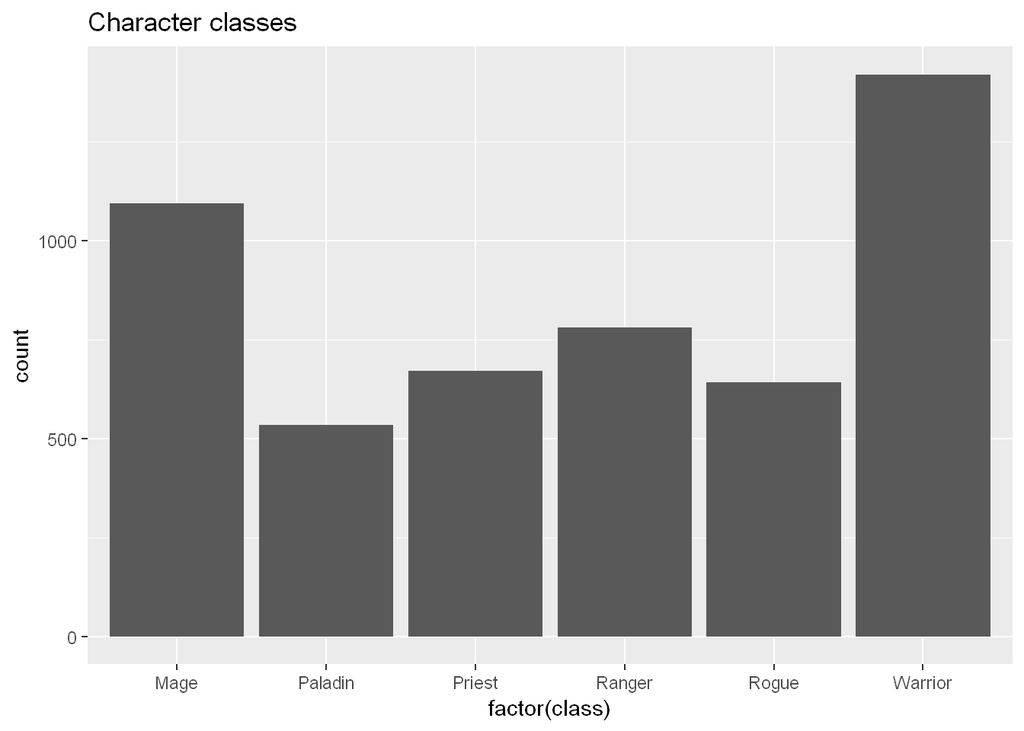

```r
remove <- which(clean_df$class == "Barbarian" | clean_df$class == "Druid" | clean_df$class == "Blackguard" | clean_df$class == "Necromancer")
clean_df2 <- clean_df[-remove,]

class_freq <- summary(factor(clean_df2$class))
class_freq <- round(100*(class_freq/sum(class_freq)),2)

library(ggplot2)
clean_df2 %>%
  ggplot(aes(x = factor(class))) + geom_bar() + ggtitle("Character classes")
```

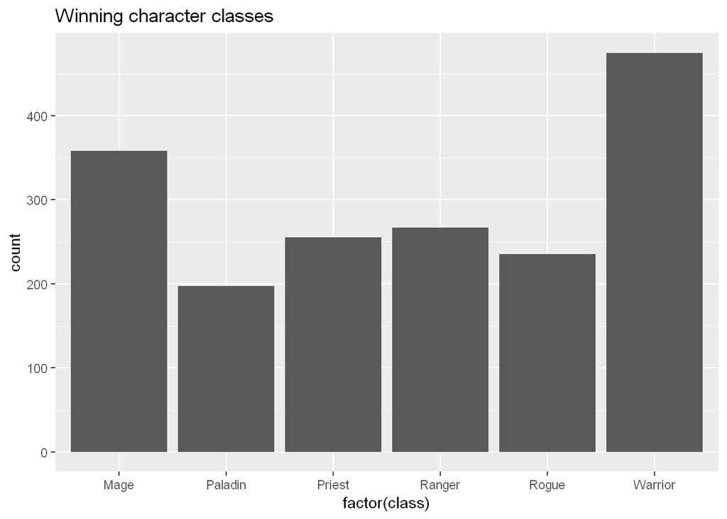

```r
clean_df2 %>%
  filter(status == "winner") %>%
  ggplot(aes(x = factor(class))) + geom_bar() + ggtitle("Winning character classes")
```

Notice now how the distribution of character classes on the ladder differs very little from the distribution of character classes of winners! This probably means that character class is not a good predictor of who will win. This is counter intuitive to me at first, but then I realize that this makes sense if you consider that Angband wins depend more on the gear that is found than the initial class choice.

Another question we might have is, who are the veterans choosing for their classes?

This question is almost impossible to answer. Most people do not submit character dumps. I played Angband for almost 20 years before finally winning and sumbitting a character dump (under the user name: forcesofodin, and the character name: Nolin.)

```r
by <- factor(clean_df2$by)
people <- levels(by)
summary(by)
```

```
##                   Estie          Ingwe Ingweron               Egavactip
##                     184                     100                      98
##              old_school              PowerDiver              Wanderlust
##                      54                      54                      54
##                Sirridan         urmud@urmud.com               Pete Mack
##                      48                      44                      41
##                 Angrist                  fizzix                nullfame
##                      40                      37                      37
##                  wobbly                Ed_47569       garnet@aufait.net
##                      37                      35                      33
##                  Sphara                   Zikke  christusrex@outgun.com
##                      31                      31                      30
##                   yarps    conrad_zaar@yahoo.ca                     nic
##                      30                      29                      29
##                 Quendus               dionysian                rdermyer
##                      29                      28                      28
##             Ycombinator                 Narvius             Thraalbeast
##                      27                      26                      26
##                  Grotug               Thraalbee                   MattB
##                      25                      25                      24
##                   Nomad TheOtherMITZE@yahoo.com              Bee Vortex
##                      24                      23                      22
##                Flestrin                 StMicah    washburn@kanservu.ca
##                      22                      22                      22
##         wmullin@nyx.net                mbell999           Donald Jonker
##                      22                      21                      20
##         drchung@rcn.com         Fendell Orcbane        stilez@gmail.com
##                      20                      20                      20
## edpentney@hotmail.co.uk                Sideways                  azfalt
##                      19                      19                      18
##                 donalde        Malak Darkhunter                sandtrap
##                      18                      18                      18
##            Cardinal Rob           Dragonboneman                Matthias
##                      17                      17                      17
##              will_asher                    Adam                 Rei Tei
##                      17                      16                      16
##                Bombadil                 fruviad iridia@pakistanmail.com
##                      15                      15                      15
##                Londorth                Mondkalb                    bron
##                      15                      15                      14
```

[output cut: 13 more lines]

```
##                      11                      11                      11
##   keith.hearn@gmail.com      mmagch@hotmail.com                  Tartek
##                      11                      11                      11
## travis_lund@hotmail.com                    eMeM                 gdunbar
##                      11                      10                      10
##              Jungle_Boy                miyazaki   myemailaint@gmail.com
##                      10                      10                      10
##                    orti                  Philip        rfry11@gmail.com
##                      10                      10                      10
##   robert.kunz@gmail.com                  tprice           UglySquirrell
##                      10                      10                      10
##               AceRimmer                Amnekian      batanu44@gmail.com
##                       9                       9                       9
##                 (Other)
##                    2835
```

```r
veterans <- names(summary(by)>9 & summary(by) < 2000)
veterans <- veterans[-length(veterans)]
veterans
```

```
##  [1] "Estie"                   "Ingwe Ingweron"
##  [3] "Egavactip"               "old_school"
##  [5] "PowerDiver"              "Wanderlust"
##  [7] "Sirridan"                "urmud@urmud.com"
##  [9] "Pete Mack"               "Angrist"
## [11] "fizzix"                  "nullfame"
## [13] "wobbly"                  "Ed_47569"
## [15] "garnet@aufait.net"       "Sphara"
## [17] "Zikke"                   "christusrex@outgun.com"
## [19] "yarps"                   "conrad_zaar@yahoo.ca"
## [21] "nic"                     "Quendus"
## [23] "dionysian"               "rdermyer"
## [25] "Ycombinator"             "Narvius"
## [27] "Thraalbeast"             "Grotug"
## [29] "Thraalbee"               "MattB"
```

[output cut: 35 more lines]

```r
head(df)
```

[output not shown]